# Caso Pŕactico Titanic

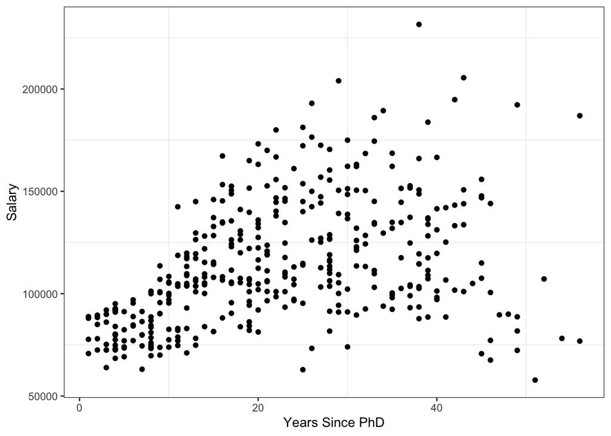

```r
# Scatter plot: Years Since PhD vs Salary
ggplot(data, aes(x = yrs.since.phd, y = salary)) +
  geom_point() +
  labs(x = "Years Since PhD", y = "Salary") +
  theme_bw() +
  theme(panel.grid.major = element_blank()) +
  scale_color_manual(values = cool_colors)
```

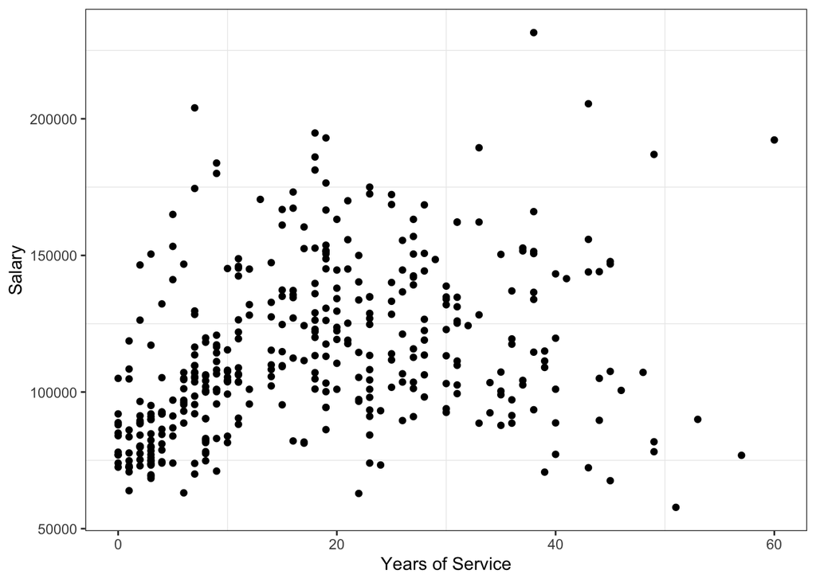

```r
# Scatter plot: Years of Service vs Salary
ggplot(data, aes(x = yrs.service, y = salary)) +
  geom_point() +
  labs(x = "Years of Service", y = "Salary") +
  theme_bw() +
  theme(panel.grid.major = element_blank()) +
  scale_color_manual(values = cool_colors)
```

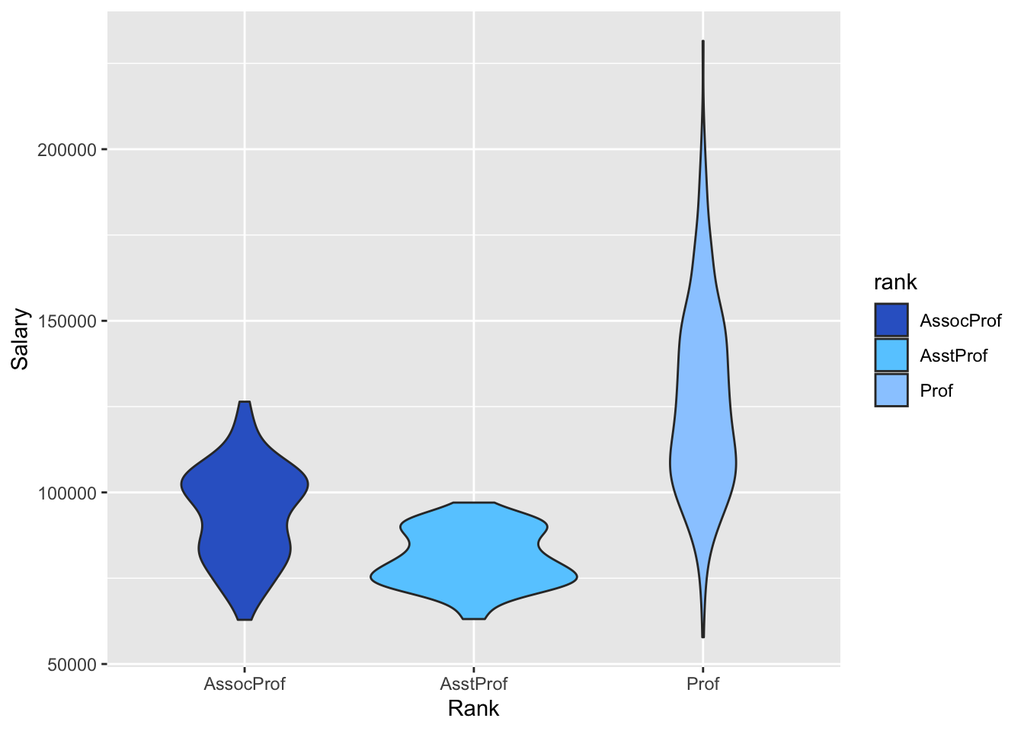

```r
ggplot(data, aes(x = rank, y = salary, fill = rank)) +
  geom_violin() +
  labs(x = "Rank", y = "Salary") +
  scale_fill_manual(values = cool_colors)
```

# Discipline:

# Yrs.since.Phd/Yrs of Service:

Se ve que el scatterplot de Yrs.since.Phd una tendencia lineal general, pero en el de Yrs of service no se ve tan claramente y será más sesgado por los outliers de profesores ganando más de 175 mil con menos años de tenure. Para esta variable habrá que estudiar su nivel de importancia estadistico porque puede ser que al transferir de otra institucion el salaro emepezará más alto.

# Rank:

El diagrama de violin para los distintos levels (Profesor Asistente, Profesor Asociado y Profesor) muestran variaciones en el salario según el rank. Esto indica que existen diferencias salariales en función del rank académico de los profesores.

# Sex:

```r
gender_count <- table(data$sex)
male_count <- gender_count[1]
female_count <- gender_count[2]

cat("Male count:", male_count, "\n")
```

```
## Male count: 358
```

```r
cat("Female count:", female_count, "\n")
```

```
## Female count: 39
```

2. ¿Podemos emplear un test paramétrico para determinar si las medias de salarios entre hombres y mujeres son las mismas o difieren? Ten en cuenta que, en tanto que se pide usar un test paramétrico, se deberá determinar si las muestras cumplen con las hipótesis necesarias.

# En este caso, una prueba paramétrica adecuada para comparar las medias de dos grupos independientes (profesores y profesoras) es la prueba t de dos muestras. Sin embargo, antes de realizar la prueba t, debemos asegurarnos de que se cumplan los supuestos de la prueba. Aquí están las hipótesis y suposiciones necesarias para la prueba t:

# Hipótesis:

Hipótesis nula (H0): Los salarios medios de los profesores y profesoras son iguales. Hipótesis alternativa (HA): Los salarios medios de los profesores y profesoras son diferentes.

# Suposiciones:

Independencia: Los salarios de los profesores y profesoras son independientes entre sí. Normalidad: Los salarios dentro de cada grupo (masculino y femenino) se distribuyen normalmente. Igualdad de varianzas: Las varianzas de los salarios en los dos grupos son iguales.

# Para determinar si se cumplen estos supuestos, puede realizar los siguientes pasos:

# 1:

Si los datos se recolectaron aleatoriamente y no hay razón para sospechar dependencia, es probable que se cumpla esta suposición.

# 2

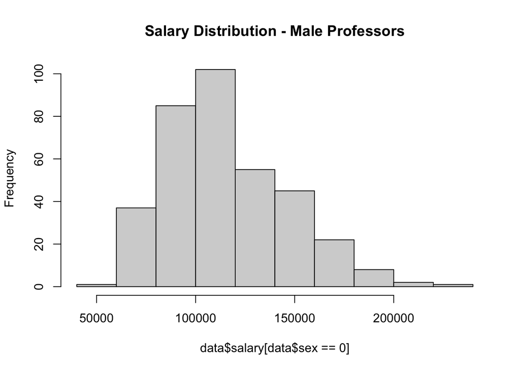

```r
hist(data$salary[data$sex == 0], main = "Salary Distribution - Male Professors")
```

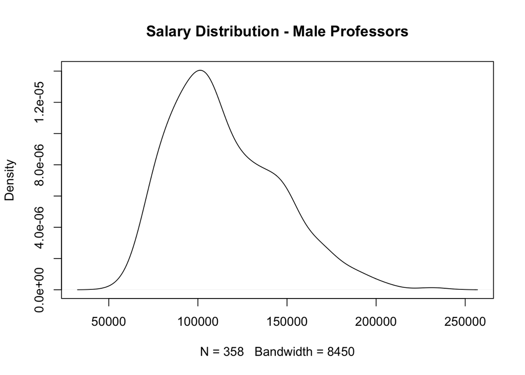

```r
plot(density(data$salary[data$sex == 0]), main = "Salary Distribution - Male Professors")
```

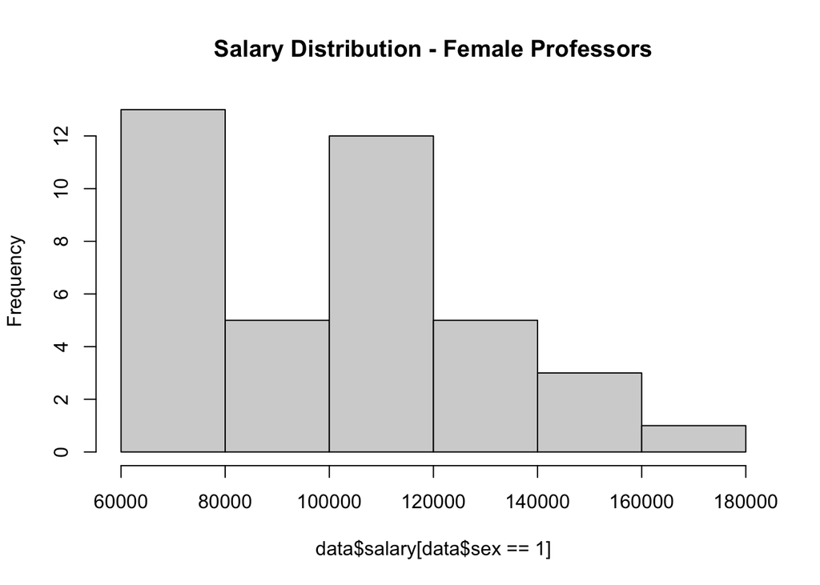

```r
hist(data$salary[data$sex == 1], main = "Salary Distribution - Female Professors")
```